# Practical Sheet 4 Solutions

### Question 1

The data below refers to violent crime rates for a random sample of 20 American areas in 2013 and 2015. The same areas are used both years so the samples are paired. The values show the number of reported crimes per 100,000 population.

```
y2013=c(613.8, 453.1, 826.7, 322.2, 640.9, 807.1, 716.7, 190.9, 217.7,
125.1, 553.1, 914.1, 409.6, 53.7, 487.8, 342.8, 120, 171.8, 190.9,
237.2)
y2015=c(610.5, 571.2, 1157.2, 485.5, 934.6, 950.1, 720.1, 288, 298.6,
75.7, 575.8, 1072.1, 631, 33.3, 460.2, 377, 144.5, 161.5, 225.7,
269.5)
```

We can construct a confidence interval using the command t.test, using the subcommmands conf.level=0.99 to control the confidence level and paired=T to specify that the data is paired.

[output not shown]

The 99% CI for the difference in population means, taking y2013-y2015, is $(-13.64, -151.1).$ Since 0 is not included in the interval, it is likely that there is a difference between the years. It looks as if crime has increased. This test is valid if the differences appear normally distributed. The stem diagram and boxplot below are slightly skewed but do not show any major problems with normality.

```
ydiff=y2013-y2015
stem(ydiff)
```

```
  The decimal point is 2 digit(s) to the right of the |

  -3 | 3
  -2 | 92
  -1 | 66420
  -0 | 8333220
   0 | 01235
```

```
boxplot(ydiff)
```

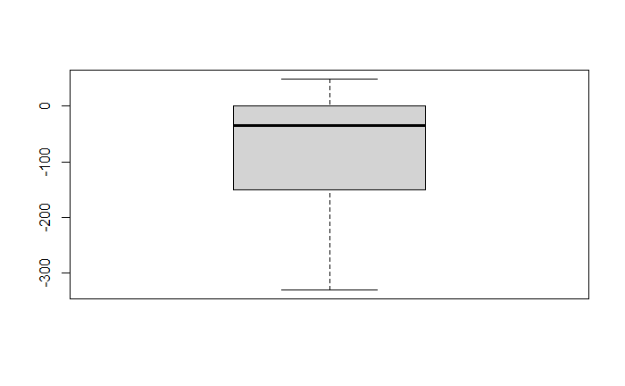

```
plot(y2013,y2015)
```

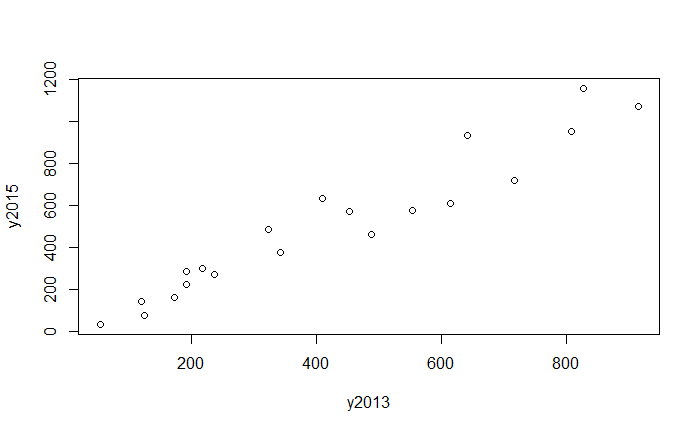

[output not shown]

### Question 2

We have the following data

```
data2=c(12.4, 16.7, 20.5, 17, 10.6, 14.9, 16.8, 21.6, 17.7, 10.2, 15.1,
18.2, 19.3, 21, 15.8)
```

To obtain a $95\%$ confidence interval for the underlying population mean we use the pivotal quantity
$$\frac{\bar{X}-\mu}{S/\sqrt{n}}$$
which is distributed according to a $t_{n-1}$-distribution assuming the underlying population is normally distributed. Let us investigate these assumptions with a box plot and histogram

[output not shown]

```
t.test(data2, conf.level = 0.95)
```

```
    One Sample t-test

data:  data2
t = 18.301, df = 14, p-value = 3.571e-11
alternative hypothesis: true mean is not equal to 0
95 percent confidence interval:
 14.58389 18.45611
sample estimates:
mean of x
    16.52
```

We obtain the Confidence interval
$$(14.58,18.45).$$

Now if we perform a hypothesis test with
$$H_0: \mu =18.5 \text{ vs } \mu\neq 18.5$$
we have

```
t.test(data2, alternative = "two.sided", mu = 18.5)
```

```
    One Sample t-test

data:  data2
t = -2.1934, df = 14, p-value = 0.04566
alternative hypothesis: true mean is not equal to 18.5
95 percent confidence interval:
 14.58389 18.45611
sample estimates:
mean of x
    16.52
```

Since $18.5$ is not included in this CI it seems we can reject $H_0$ at a $95\%$ significance level. Moreover the $p$-value of 0.04566 there is some evidence to reject $H_0$. It seems that the data do not come from a population with mean 18.5.

### Question 3

For the hypothesis
$$H_0: \mu=15 \text{ vs } H_1: \mu>15$$
we use

```
t.test(data2,alternative = "greater",mu=15)
```

```
    One Sample t-test

data:  data2
t = 1.6838, df = 14, p-value = 0.05718
alternative hypothesis: true mean is greater than 15
95 percent confidence interval:
 14.93006      Inf
sample estimates:
mean of x
    16.52
```

Since the p-value is just over 0.05, there is weak evidence that the population mean is greater than 15.

For the hypothesis
$$H_0: \mu=14 \text{ vs } H_1: \mu>14$$

we use

```
t.test(data2,alternative = "greater",mu=14)
```

```
    One Sample t-test

data:  data2
t = 2.7916, df = 14, p-value = 0.007208
alternative hypothesis: true mean is greater than 14
95 percent confidence interval:
 14.93006      Inf
sample estimates:
mean of x
    16.52
```

Since the $p$-value is very low, there is strong evidence that the population mean is greater than $14$.

For the hypothesis
$$H_0: \mu=13 \text{ vs } H_1: \mu>13$$

we use

[output not shown]

The $p$-value here is $0.0008018$ so overwhelming evidence against the null hypothesis that the population mean is $13$.

### Question 4

```
data4=c(241, 251, 258, 246, 202, 246, 246, 301, 260, 228, 275, 266,
264, 250, 258, 265, 240, 227, 271, 306, 269, 252, 242, 274, 222,
244, 218, 228, 247, 202, 287, 279, 242, 262, 268, 226, 303, 214,
242, 233)
```

We perform a two-sided hypothesis test to test the hypothesis

$$H_0: \mu=260 \text{ vs } H_1: \mu\neq 260$$

[output not shown]

The $p$-value suggests we have evidence to reject the null hypothesis. It does not seem plausible that these data come from a population with mean $260$.

### Question 5

```
pixel=c(68, 75, 65, 69, 70, 72, 65, 66, 58, 62)
negative=c(59, 61, 62, 57, 64, 57, 60, 61, 51, 55)
t.test(pixel, negative, var.equal = TRUE, alternative = "greater")
```

```
    Two Sample t-test

data:  pixel and negative
t = 4.2203, df = 18, p-value = 0.0002572
alternative hypothesis: true difference in means is greater than 0
95 percent confidence interval:
 4.889675      Inf
sample estimates:
mean of x mean of y
     67.0      58.7
```

Since the $p$-value is $0.0002572$, there is overwhelming evidence that more facts are remembered by the population of subjects who view the witness by `pixilation'' than by those who view the witness by`negative image’’.

### Question 6

```
realdat=c(40, 35, 50, 55, 65, 55, 50, 35, 30, 50, 60, 40)
picture=c(30, 35, 45, 40, 50, 35, 55, 25, 30, 45, 40, 50)
t.test(realdat,picture,alternative="greater",paired=T)
```

```
    Paired t-test

data:  realdat and picture
t = 2.5445, df = 11, p-value = 0.01363
alternative hypothesis: true mean difference is greater than 0
95 percent confidence interval:
 2.084005      Inf
sample estimates:
mean difference
       7.083333
```

The $p$-value of $0.01363$ means that we have evidence against the null hypothesis. Therefore we can conclude that in the population, real spiders evoke greater levels of anxiety as compared to pictures of spiders.